# Suspicion Index for llmpanel

### ReCaptcha Score

We are concerned with responses with low or NA captcha scores. These scores are a direct probability measure of whether or not a respondent is a human being (and not a bot), provided by Qualtrics through ReCaptcha proprietary methods. While scores below 0.5 were automatically rejected from our sample, remaining values can be as low as 0.5 or NA in the event that a 3rd party survey provider contracted through Qualtrics did not share a score for their respondents.

*Distributions*

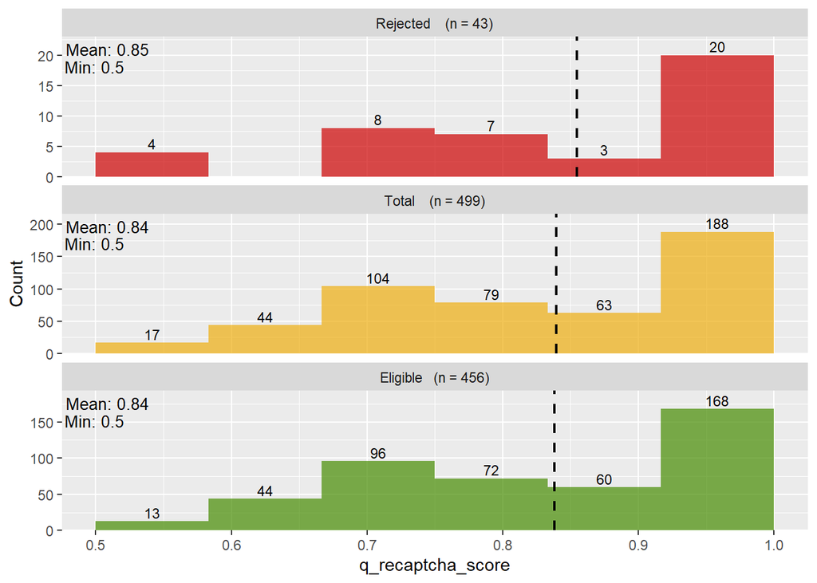

```r
compare_plot("q_recaptcha_score", stat = 'mean', bins =6, display = "min", labels = "left")
```

Captcha is an essential first step for identifying bots. As such, it feels proper to include suspicion for our lowest scores of 0.5, as well as NAs.

*Construct captcha flag variable*

```r
# Flag minimum values of 0.5 & NAs
panel <- panel |>
  mutate(
    captcha_sus = q_recaptcha_score <= 0.5 |
                  is.na(q_recaptcha_score)
    )

# Redefine eligible, rejected, and combined subsets
split_panel(panel)
```

*Proportions*

```r
prop_table("captcha_sus")
```

```
# A tibble: 3 × 3
  group          n_true   prop
  <chr>           <int>  <dbl>
1 Rejected n=43       5 0.116
2 Full n=499         21 0.0421
3 Eligible n=456     16 0.0351
```

While the histogram comparison did not indicate a major difference in the distribution of scores between the eligible and rejected subsets, our constructed captcha flag does see a higher proportion of suspicious responses among the rejected!

### Audit Score

We are concerned with respondents who may have exaggerated AUDIT responses in an attempt to screen into the survey for compensation. A threshold of “perfect” AUDIT scores of 40 will be used for the index, which can also be thought of as another instance of straight-lining.

*Distributions*

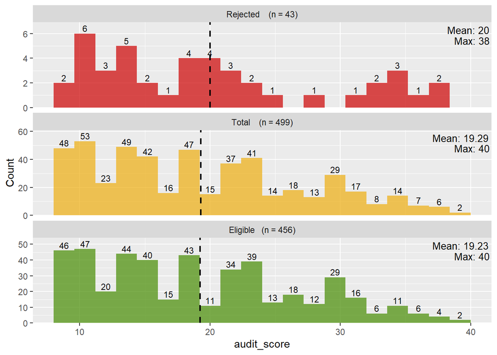

```r
compare_plot("audit_score", bins = 20, stat = "mean", display = "max")
```

```r
panel |> filter(!is.na(audit_score)) |> nrow()
```

```
[1] 3886
```

```r
panel |> filter(!is.na(audit_score)) |>
  count(audit_score) |> arrange(desc(audit_score)) |> print(n=40)
```

```
# A tibble: 41 × 2
   audit_score     n
         <dbl> <int>
 1          40    13
 2          39    18
 3          38    17
 4          37    26
 5          36    44
 6          35    59
 7          34    58
 8          33    66
 9          32    79
10          31    86
11          30    95
12          29    87
```

[output cut: 29 more lines]

```r
panel |> filter(audit_score == 40) |> count(flag)
```

```
# A tibble: 3 × 2
  flag                  n
  <chr>             <int>
1 att_check            10
2 q_recaptcha_score     1
3 <NA>                  2
```

It first looks like we lack supporting evidence with the rejected subset containing no responses with a max audit score of 40, but this is also reasonably expected given how rare a max score is and the small size of the rejected subset. Out of the 3886 survey attempts that got through the AUDIT, only 13 provided a perfect score of 40. With only 2 of these cases making their way into eligible sample, the remaining 11 automatically flagged out on either a captcha or attention-check failure.

All that said, it feels proper to include suspicion for max value AUDIT scores.

*Create AUDIT flag variable*

```r
# Flag "perfect" 40/40 scores
panel <- panel |>
  mutate(
    audit_sus = audit_score == 40
  )

# Redefine eligible, rejected, and combined subsets
split_panel(panel)
```

### GPS Data

We are concerned with respondents having a large discrepancy between their reported and observed location, which may indicate VPN usage or other identity-masking attempts. The gps_diff variable contains the lowest of two value:

- Distance from reported city/state to IP address location
- Distance from reported city/state to reported grocery store

*Distributions*

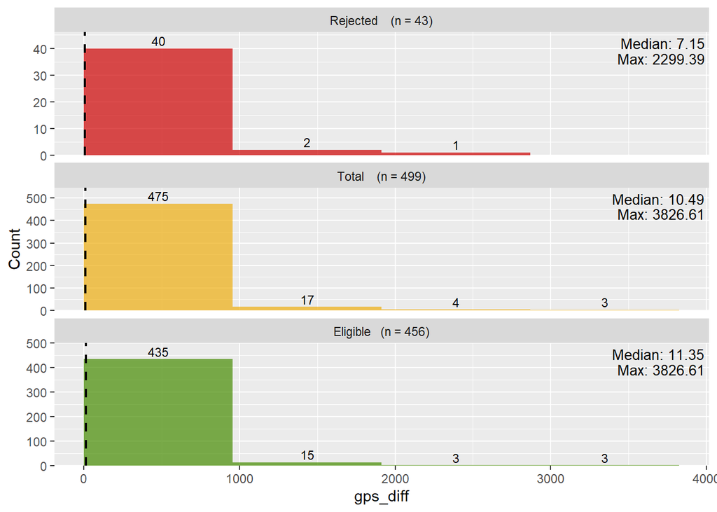

```r
compare_plot("gps_diff", bins = 4, display = "max", stat = "median")
```

As with AUDIT scores, this may be another case where the small rejected subset size is the reason why we don’t see as many outliers when compared to the eligible subset. Regardless, a distance of hundreds or thousands of kilometers is convincingly suspicious.

```r
mad(p_eligible$gps_diff)
```

```
[1] 15.59982
```

```r
p_eligible |> filter(gps_diff > 500) |> nrow()
```

```
[1] 39
```

While a lower threshold could be set for establishing suspicion, the large 500km number was chosen for two reasons:

1. There are some genuine explanations for large distances - IP addresses behave weirdly for smartphones completing the survey through cellular data, respondents living in very rural areas, etc. This current threshold should excuse most of these honest discrepancies, leaving suspicion primarily for distances so egregious that something is definitely wrong.
2. Lower thresholds do not create the increase in flagged proportion between the valid and rejected subset that we are in part using to calibrate the suspicion index. By 500km it has become pronounced enough to support the inclusion of this component.

*Create GPS flag*

```r
# Flag responses with a distance over 500km
panel <- panel |>
  mutate(
    gps_sus = gps_diff > 500
  )

# Redefine eligible, rejected, and combined subsets
split_panel(panel)
```

*Proportions*

```r
prop_table('gps_sus')
```

```
# A tibble: 3 × 3
  group          n_true   prop
  <chr>           <int>  <dbl>
1 Rejected n=43       5 0.116
2 Full n=499         44 0.0882
3 Eligible n=456     39 0.0855
```

The flag threshold sees the rejected subset show a higher proportion of suspicious responses.